# MH3511 Lab 7 Notes

Caleb Tay (caleb.tay@ntu.edu.sg)

19 Mar 2026

# Exercise 7.1

```r
set.seed(100)
b <- 10000
n <- 200
mu <- 4
rate = 1/mu
alpha <- 0.1

CI90 <- function(n, mu, alpha) {
  ds <- rexp(n, rate=1/mu)
  xbar <- mean(ds)
  sd <- sd(ds)

  # lbd <- qnorm(1-alpha/2, xbar, sd / sqrt(n))
  lbd <- xbar - qnorm(1-alpha/2) * sd / sqrt(n)
  ubd <- xbar + qnorm(1-alpha/2) * sd / sqrt(n)

  return(c(lbd, ubd))
}


set.seed(100)
confint <- replicate(b, CI90(n, mu, alpha))
dim(confint)
```

```
## [1]     2 10000
```

```r
in_range <- confint[1,] <= mu & mu <= confint[2,]
mean(in_range)
```

```
## [1] 0.8921
```

```r
set.seed(100)
confint <- NULL
for (i in 1:b) confint <- rbind(confint, CI90(n, mu, alpha))
dim(confint)
```

```
## [1] 10000     2
```

```r
in_range <- confint[,1] <= mu & mu <= confint[,2]
mean(in_range)
```

```
## [1] 0.8921
```

# Exercise 7.2

```r
smoker <- read.table('smoker.txt', header=T)
summary(smoker)
```

```
##     Smoke               SES
##  Length:356         Length:356
##  Class :character   Class :character
##  Mode  :character   Mode  :character
```

```r
smoker[1:2] <- lapply(smoker[1:2], as.factor)
summary(smoker)
```

```
##      Smoke         SES
##  current:116   High  :211
##  former :141   Low   : 93
##  never  : 99   Middle: 52
```

```r
smoker <- read.table('smoker.txt', header=T)
smoker$Smoke <- as.factor(smoker$Smoke)
smoker$SES <- factor(smoker$SES)
summary(smoker)
```

```
##      Smoke         SES
##  current:116   High  :211
##  former :141   Low   : 93
##  never  : 99   Middle: 52
```

```r
smoker.table <- table(smoker)
smoker.table
```

```
##          SES
## Smoke     High Low Middle
##   current   51  43     22
##   former    92  28     21
##   never     68  22      9
```

```r
margin.table(smoker.table)
```

```
## [1] 356
```

```r
sum(smoker.table)
```

```
## [1] 356
```

```r
margin.table(smoker.table, 1)
```

```
## Smoke
## current  former   never
##     116     141      99
```

```r
rowSums(smoker.table)
```

```
## current  former   never
##     116     141      99
```

```r
margin.table(smoker.table, 2)
```

```
## SES
##   High    Low Middle
##    211     93     52
```

```r
colSums(smoker.table)
```

```
##   High    Low Middle
##    211     93     52
```

The bar chart below represents the smoke status among each SES group. If there were no dependence of smoking status on SES, we would expect each SES group to have similar proportions of smoking status.

However, we can clearly see that the current smokers constitute the *smallest proportion* of the High SES group, but the *largest population* of the Low SES group.

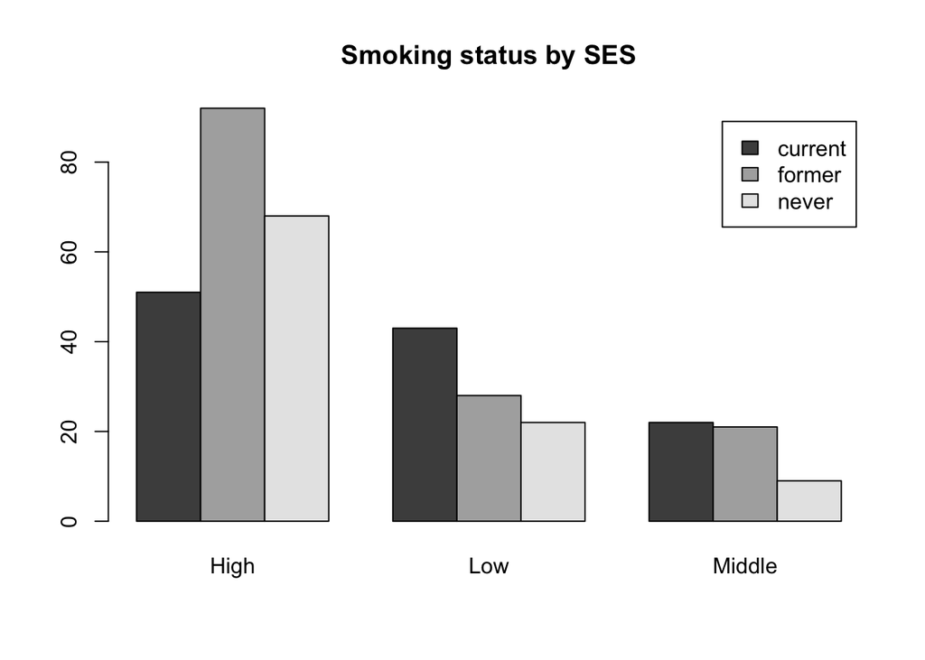

```r
barplot(smoker.table, legend=T, beside=T, main="Smoking status by SES")
```

It might be easier to look at each group without considering the population size, as the notes suggest, and instead just the proportions of current smokers, former smokers, and never smokers within each SES group.

```r
smoker.prop.table <- prop.table(smoker.table, 2)
smoker.prop.table
```

```
##          SES
## Smoke          High       Low    Middle
##   current 0.2417062 0.4623656 0.4230769
##   former  0.4360190 0.3010753 0.4038462
##   never   0.3222749 0.2365591 0.1730769
```

```r
colSums(smoker.prop.table)
```

```
##   High    Low Middle
##      1      1      1
```

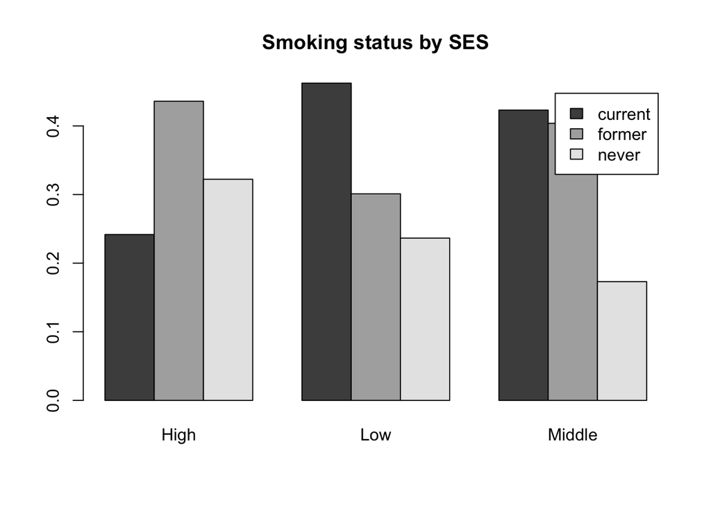

```r
barplot(smoker.prop.table, legend=T, beside=T, main="Smoking status by SES")
```

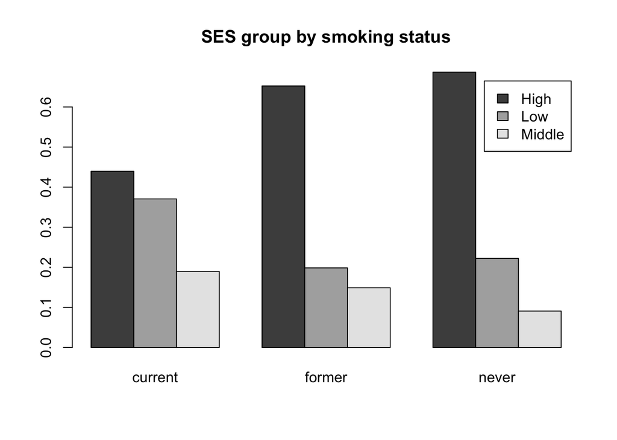

```r
smoker.prop.table <- prop.table(smoker.table, 1)
barplot(t(smoker.prop.table), legend=T, beside=T, main="SES group by smoking status")
```

If there are no dependencies, then the probabilities (and thus expectations) are independent of each other.

$$P(\textrm{smoker = current, SES = High}) = P(\textrm{smoker = current})
P(\textrm{SES = High})$$
We can get the probabilities of each by counting each of them and get the expectation for each group by multiplying the two:

```r
smoker.table
```

```
##          SES
## Smoke     High Low Middle
##   current   51  43     22
##   former    92  28     21
##   never     68  22      9
```

```r
p.smoke <- margin.table(smoker.table, 1) / sum(smoker.table)
p.smoke
```

```
## Smoke
##   current    former     never
## 0.3258427 0.3960674 0.2780899
```

```r
p.ses <- margin.table(smoker.table, 2) / sum(smoker.table)
p.ses
```

```
## SES
##      High       Low    Middle
## 0.5926966 0.2612360 0.1460674
```

```r
p.expected <- outer(p.smoke, p.ses)
expected <- p.expected * sum(smoker.table)
expected
```

```
##          SES
## Smoke         High      Low   Middle
##   current 68.75281 30.30337 16.94382
##   former  83.57022 36.83427 20.59551
##   never   58.67697 25.86236 14.46067
```

```r
p.smoke <- rowSums(smoker.table) / sum(smoker.table) #same result as above
p.ses <- colSums(smoker.table) / sum(smoker.table)   #same result as above
matrix(p.smoke, nrow = 3) %*% matrix(p.ses, ncol=3) * sum(smoker.table)
```

```
##          [,1]     [,2]     [,3]
## [1,] 68.75281 30.30337 16.94382
## [2,] 83.57022 36.83427 20.59551
## [3,] 58.67697 25.86236 14.46067
```

The chi-square test:

```r
chi.sq.stat <- sum((smoker.table - expected)^2/expected)
chi.sq.stat
```

```
## [1] 18.50974
```

```r
1 - pchisq(chi.sq.stat, 4)
```

```
## [1] 0.0009808236
```

```r
summary(smoker.table)
```

```
## Number of cases in table: 356
## Number of factors: 2
## Test for independence of all factors:
##  Chisq = 18.51, df = 4, p-value = 0.0009808
```

# Exercise 7.3

We will use the `table` data format to store our data. It is known as a contingency table, showing the frequency of some data.

We arrange the data in a matrix first, and then use the `as.table()` function to convert it into a table.

The `table()` function directly creates things from data (like in the above), counting the frequency, while the `as.table()` function does not process the data further.

```r
hospital <- matrix(c(16, 654, 24, 306), nrow=2, ncol=2)
hospital <- as.table(hospital)
rownames(hospital) <- c("No", "Yes")
colnames(hospital) <- c("Day", "Evening")
hospital
```

```
##     Day Evening
## No   16      24
## Yes 654     306
```

If we assume there is no relation between the two factors (in this context, conformance and shift), then we can treat them independently. For example:

$$P(\textrm{conforms = Yes, shift = Day}) =
P(\textrm{conforms = Yes}) \times P(\textrm{shift = Day})$$

Typically our tests will be $H_0:$ there is no relation between the variables (i.e. they are independent), $H_1:$ there is a relation between the variables.

So we can calculate the expected frequency under the null hypothesis since we can get the marginal probabilities $P(\textrm{conforms = Yes})$ and $P(\textrm{shift = Day})$.

```r
p.conforming <- margin.table(hospital, 1) / sum(hospital)
p.conforming
```

```
##   No  Yes
## 0.04 0.96
```

```r
p.shift <- margin.table(hospital, 2) / sum(hospital)
p.shift
```

```
##     Day Evening
##    0.67    0.33
```

The expected proportions **if there is no relation** can then be calculated from our data:

$$\begin{align*}
\left[
\begin{matrix}
P(\textrm{C = No}) \\ P(\textrm{C = Yes})
\end{matrix}
\right]= \left[
\begin{matrix}
0.04 \\ 0.96
\end{matrix}
\right]
\textrm{ and }
\left[
\begin{matrix}
P(\textrm{S = Day}) \\ P(\textrm{S = Night})
\end{matrix}
\right]= \left[
\begin{matrix}
0.67 \\ 0.33
\end{matrix}
\right]
\end{align*}$$

$$\begin{align*}
\left[
\begin{matrix}
P(\textrm{C = No}) P(\textrm{S = Day}) &
P(\textrm{C = No}) P(\textrm{S = Night}) \\
P(\textrm{C = Yes}) P(\textrm{S = Day}) &
P(\textrm{C = Yes}) P(\textrm{S = Night}) \\
\end{matrix}
\right]= \left[
\begin{matrix}
0.04 \times 0.67 & 0.04 \times 0.33 \\
0.96 \times 0.67 & 0.96 \times 0.33
\end{matrix}
\right]= \left[
\begin{matrix}
0.0268 & 0.0132 \\
0.6432 & 0.3168
\end{matrix}
\right]
\end{align*}$$

In R, we can calculate it with the outer product. The outer product creates a matrix from its inputs, where each entry is the multiplication of single elements in each vector, similar to the matrices shown above.

```r
p.expected <- outer(p.conforming, p.shift)
p.expected
```

```
##        Day Evening
## No  0.0268  0.0132
## Yes 0.6432  0.3168
```

```r
expected <- p.expected * sum(hospital)
expected
```

```
##       Day Evening
## No   26.8    13.2
## Yes 643.2   316.8
```

```r
hospital
```

```
##     Day Evening
## No   16      24
## Yes 654     306
```

Another way using matrix multiplication directly, but we lose the row and column headers (unless we add them back in):

```r
matrix(p.conforming, nrow=2) %*% matrix(p.shift, ncol=2)
```

```
##        [,1]   [,2]
## [1,] 0.0268 0.0132
## [2,] 0.6432 0.3168
```

Having the expected frequencies, we can then calculate the chi-square statistic.

```r
chisq.stat <- sum((expected - hospital)^2/expected)
chisq.stat
```

```
## [1] 13.73813
```

```r
1 - pchisq(chisq.stat, 1)
```

```
## [1] 0.0002101449
```

```r
chisq.test(hospital, correct=F)
```

```
##
##  Pearson's Chi-squared test
##
## data:  hospital
## X-squared = 13.738, df = 1, p-value = 0.0002101
```

```r
summary(hospital)
```

```
## Number of cases in table: 1000
## Number of factors: 2
## Test for independence of all factors:
##  Chisq = 13.738, df = 1, p-value = 0.0002101
```

Considering proportions according to the rows, we get the proportion of Day and Evening shift workers across whether they conformed or not.

Considering proportions according to the columns, we get the proportion of No and Yes responses across each shift.

As a lab director, the second table would be more useful as it lets us understand which shift’s workers conform to the testing procedures.

```r
hospital
```

```
##     Day Evening
## No   16      24
## Yes 654     306
```

```r
prop.table(hospital, 1)
```

```
##         Day Evening
## No  0.40000 0.60000
## Yes 0.68125 0.31875
```

```r
prop.table(hospital, 2)
```

```
##            Day    Evening
## No  0.02388060 0.07272727
## Yes 0.97611940 0.92727273
```

# Exercise 7.4

In this exercise, we have *paired data*, i.e. there are commonalities in the observations. In this case, observations are paired based on similarity in age and cancer stage. A more common context would be a before/after survey on the same individuals.

We have a total of 622 paired observations here.

```r
cancer <- matrix(c(510, 5, 17, 90), nrow=2)
cancer <- as.table(cancer)
# rownames(cancer) <- c("PO+6 Survived 5 yrs", "PO+6 Died within 5 yrs")
# colnames(cancer) <- c("PO Survived 5 yrs", "PO Died within 5 yrs")
rownames(cancer) <- c("Before Yes", "Before No")
colnames(cancer) <- c("After Yes", "After No")
cancer
```

```
##            After Yes After No
## Before Yes       510       17
## Before No          5       90
```

Our null hypothesis is that the number of changes in each direction is equally likely. Or: the probability of going from “yes” to “no” is equal to the probability of going from “no” to “yes”. Or: it is equally likely that you answered “yes” before and after the event. If we consider only these ‘switching’ (discordant) cases, then they would both have probability 0.5.

Thus we consider the ones who changed, of which there are 5 + 17 = 22 of them. Among them, if the null hypothesis is true, we would expect 11 of them to change from “yes” to “no” and 11 of them to change from “no” to “yes”.

The calculation of the test statistic is then similar to the Pearson chi-squared test. A continuity correction can be applied because the true underlying distribution is binomial in nature, similar to how (in other courses on statistics/probability) we use a normal distribution to approximate a binomial/Poisson distribution.

The formula given in the notes with continuity correction, $\frac{(|B-C| - 1)^2}{B+C}$, gives the same results as how I calculate it below.

```r
mcnemar.stat.corrected <- (abs(5 - 11) - 0.5)^2 / 11 + (abs(17-11) - 0.5)^2 / 11
mcnemar.stat.corrected
```

```
## [1] 5.5
```

```r
mcnemar.test(cancer)
```

```
##
##  McNemar's Chi-squared test with continuity correction
##
## data:  cancer
## McNemar's chi-squared = 5.5, df = 1, p-value = 0.01902
```

```r
mcnemar.stat <- (5 - 11)^2 / 11 + (17-11)^2 / 11
mcnemar.stat
```

```
## [1] 6.545455
```

```r
mcnemar.test(cancer, correct=F)
```

```
##
##  McNemar's Chi-squared test
##
## data:  cancer
## McNemar's chi-squared = 6.5455, df = 1, p-value = 0.01052
```